# trabajo_personal

```r
compañia_peores_retrasos_salida <- vuelos %>%
  group_by(carrier) %>%
  summarise(dep_delay = mean(dep_delay, na.rm = TRUE)) %>%
  arrange(desc(dep_delay))

head(compañia_peores_retrasos_salida)
```

```
## # A tibble: 6 x 2
##   carrier dep_delay
##   <chr>       <dbl>
## 1 F9           20.2
## 2 EV           20.0
## 3 YV           19.0
## 4 FL           18.7
## 5 WN           17.7
## 6 9E           16.7
```

20. Queremos saber qué hora del día nos conviene volar si queremos evitar los retrasos en la salida.

```r
hora_evitar_retrasos <- vuelos %>%
  group_by(hour) %>%
  summarise(dep_delay = mean(dep_delay, na.rm = TRUE)) %>%
  arrange(desc(dep_delay))

hora_clave <- head(hora_evitar_retrasos$hour,1)

print(paste0("Conviene salir a las ", hora_clave, "h para evitar retrasos en la salida"))
```

[output not shown]

21. Queremos saber qué día de la semana nos conviene volar si queremos evitar los retrasos en la salida.

```r
make_dtime <- function(year, month, day, time) {
  make_datetime(year, month, day, time %/% 100, time %% 100)
}

ajuste_horas <- vuelos_dt <- vuelos %>%
  filter(!is.na(dep_time), !is.na(arr_time)) %>%
  mutate(
    dep_time = make_dtime(year, month, day, dep_time),
    arr_time = make_dtime(year, month, day, arr_time),
    sched_dep_time = make_dtime(year, month, day, sched_dep_time),
    sched_arr_time = make_dtime(year, month, day, sched_arr_time)
  ) %>%
  select(origin, dest, ends_with("delay"), ends_with("time"))

vuelos_dt %>%
  mutate(dow = wday(sched_dep_time)) %>%
  group_by(dow) %>%
  summarise(
    dep_delay = mean(dep_delay),
    arr_delay = mean(arr_delay, na.rm = TRUE)
  ) %>%
  print(n = Inf)
```

```
## # A tibble: 7 x 3
##     dow dep_delay arr_delay
##   <dbl>     <dbl>     <dbl>
## 1     1     11.5       4.82
## 2     2     14.7       9.65
## 3     3     10.6       5.39
## 4     4     11.7       7.05
## 5     5     16.1      11.7
## 6     6     14.7       9.07
## 7     7      7.62     -1.45
```

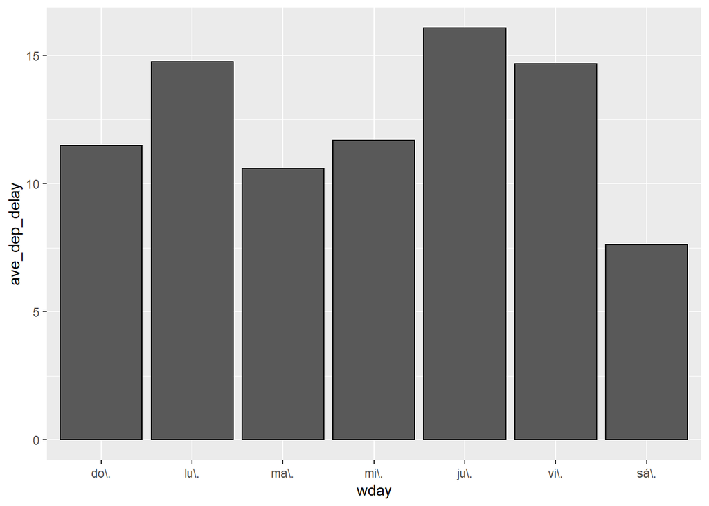

```r
vuelos_dt %>%
  mutate(wday = wday(dep_time, label = TRUE)) %>%
  group_by(wday) %>%
  summarize(ave_dep_delay = mean(dep_delay, na.rm = TRUE)) %>%
  ggplot(aes(x = wday, y = ave_dep_delay)) +
  geom_bar(stat = "identity", col = "black")
```

```r
print("Los sábados son el día de la semana donde se acumula menor retraso en la salida, seguido de los martes de cada semana. Por otro lado, los jueves, viernes y lunes son vueles suelen sufrir mayor retraso en su salida")
```

```
## [1] "Los sábados son el día de la semana donde se acumula menor retraso en la salida, seguido de los martes de cada semana. Por otro lado, los jueves, viernes y lunes son vueles suelen sufrir mayor retraso en su salida"
```

22. Para cada destino, calcula el total de minutos de retraso acumulado.

```r
retraso_llegada_destino_vuelos <- vuelos %>%
  filter(arr_delay > 0) %>%
  group_by(dest) %>%
  summarise(arr_delay = sum(arr_delay))
```

23. Para cada uno de ellos, calcula la proporción del total de retraso para dicho destino.

```r
proporcion_total_retrasos <- vuelos %>%
  filter(arr_delay > 0) %>%
  group_by(dest, origin, carrier, flight) %>%
  summarise(arr_delay = sum(arr_delay)) %>%
  group_by(dest) %>%
  mutate(
    arr_delay_prop = arr_delay / sum(arr_delay)
  ) %>%
  arrange(dest, desc(arr_delay_prop)) %>%
  select(carrier, flight, origin, dest, arr_delay_prop)
```

24. Es hora de aplicar todo lo que hemos aprendido para visualizar mejor los tiempos de salida para vuelos cancelados vs los no cancelados. Recuerda bien qué tipo de dato tenemos en cada caso. ¿Qué deduces acerca de los retrasos según la hora del día a la que está programada el vuelo de salida?

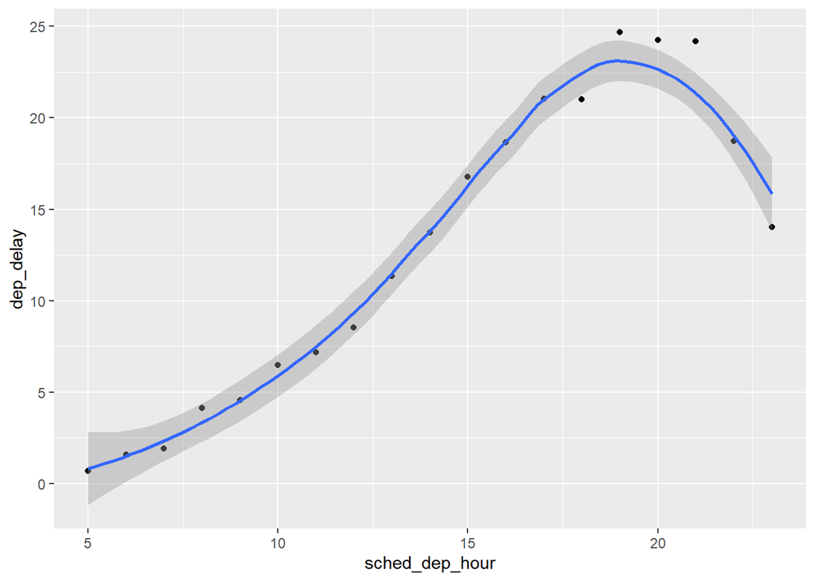

```r
vuelos_dt %>%
  mutate(sched_dep_hour = hour(sched_dep_time)) %>%
  group_by(sched_dep_hour) %>%
  summarise(dep_delay = mean(dep_delay)) %>%
  ggplot(aes(y = dep_delay, x = sched_dep_hour)) +
  geom_point() +
  geom_smooth()
```

25. Subir la carpeta a github y facilitar la url.